# STAT1003

Introduction to Data Science

Solution: Workshop 11

# Introduction

We analyzed the Alzheimer’s data in Workshop 10 using logistic regression and $K$-nearest neighbours. Here, we will analyze them using a classification tree, as well as random forests. The datasets (`testing` and `training`) are identical to those in the earlier workshop, and are contained in `S1_2019_STAT1003_Workshop_11.RData` along with the data for the Cleveland heart disease study.

Before you begin, make sure that you have the following libraries installed on your computer.

```r
library(rpart)
library(randomForest)
library(partykit)
```

```r
# Load the data here
print(load("S1_2019_STAT1003_Workshop_11.RData"))
```

```
[1] "Heart"    "testing"  "training"
```

# Alzheimer’s Data Redux

1. Recall that the response variable is `Class` and that it has two categories. What are they?

The levels are Impaired, Control.

2. Fit a classification tree to the training set using the function `rpart`, and save the results in an object. The syntax is very similar to what you would use to fit a regression model. There are many arguments, and finer-grained control can be obtained by using the function `rpart.control`, but the default result is usually pretty good.

The syntax for using `rpart` is similar to what you would use for regression:

```r
Alz.rpart <- rpart(Class ~ ., data = training)
```

3. Obtain a summary of the object you created above and see if you can understand at least some of the output.

As you may have noticed, the `summary` function produces lots of output, so I’ve suppressed some of it below using the `cp` argument. Skipping down to the section beginning with the text `Node number 1`, we can see that the output consists of each node, what alternatives the algorithm attempted, and so on.

```r
summary(Alz.rpart, cp = 0.16)
```

```
Call:
rpart(formula = Class ~ ., data = training)
  n= 267

          CP nsplit rel error    xerror       xstd
1 0.28767123      0 1.0000000 1.0000000 0.09976629
2 0.15068493      1 0.7123288 0.9041096 0.09655872
3 0.03424658      2 0.5616438 0.7397260 0.08991004
4 0.02739726      5 0.4520548 0.8356164 0.09397667
5 0.01000000      6 0.4246575 0.7671233 0.09112903

Variable importance
                          Ab_42              Creatine_Kinase_MB
                             26                               9
                          MMP10                        IGF_BP_2
                              5                               4
                            tau                       GRO_alpha
                              4                               4
B_Lymphocyte_Chemoattractant_BL                             AXL
                              3                               3
                          NrCAM                             SOD
                              3                               3
                   Betacellulin               Apolipoprotein_CI
                              3                               3
               Apolipoprotein_E                       Eotaxin_3
                              3                               3
                            CgA  Kidney_Injury_Molecule_1_KIM_1
                              3                               3
            Apolipoprotein_A_IV               Apolipoprotein_A1
                              2                               2
                           IL_8                           PAI_1
                              2                               2
                            FAS                            IL_3
                              1                               1
                       Resistin                Apolipoprotein_D
                              1                               1
 ACE_CD143_Angiotensin_Converti                 Angiotensinogen
                              1                               1
               Apolipoprotein_B                           IL_13
                              1                               1
```

[output cut: 17 more lines]

```
      Apolipoprotein_E    < 1.554584    to the left,  agree=0.749, adj=0.107, (0 split)
      tau                 < 6.443672    to the right, agree=0.749, adj=0.107, (0 split)
      Apolipoprotein_A_IV < -2.659668   to the left,  agree=0.742, adj=0.080, (0 split)
      Apolipoprotein_A1   < -8.198905   to the left,  agree=0.742, adj=0.080, (0 split)
      Apolipoprotein_CI   < -2.275341   to the left,  agree=0.742, adj=0.080, (0 split)

Node number 2: 75 observations
  predicted class=Impaired  expected loss=0.36  P(node) =0.2808989
    class counts:    48    27
   probabilities: 0.640 0.360

Node number 3: 192 observations
  predicted class=Control   expected loss=0.1302083  P(node) =0.7191011
    class counts:    25   167
   probabilities: 0.130 0.870
```

The first split occurs with the variable `Ab_42`, with a second possibility being the variable `tau`, and we can see from the plots below that a split of `Ab_42 < 11.28742` separates the classes better than the split of `tau < 5.744661`.

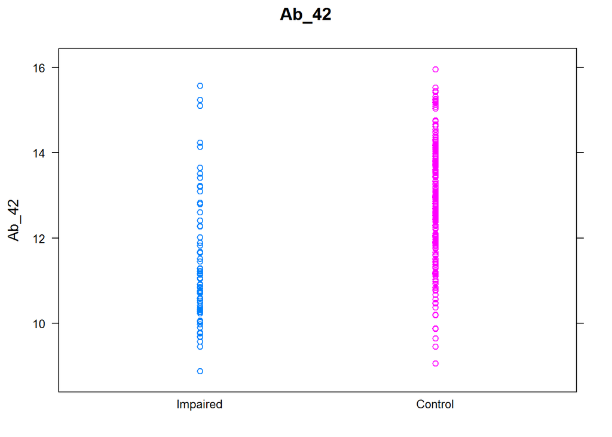

```r
require(lattice)
par(mfrow = c(1, 2))
stripplot(Ab_42 ~ Class, data = training, main = "Ab_42", groups = Class)
```

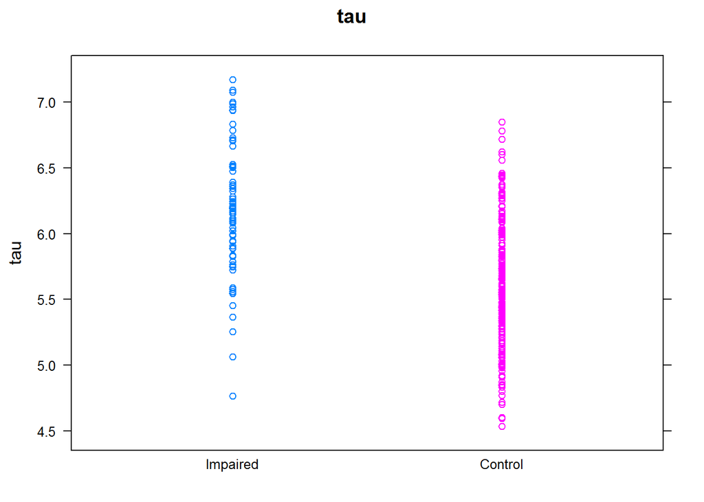

```r
stripplot(tau ~ Class, data = training, main = "tau", groups = Class)
```

4. Plot the resulting tree using the function `plot` followed by the function `text` to add labels to the tree. You will see that using default values of the arguments does *not* produce a very appealing graphic! Make the tree bigger by trying different values of `fig.width` and `fig.height` **inside the chunk header**. Once you have constructed the tree, make sure you know how to interpret the result.

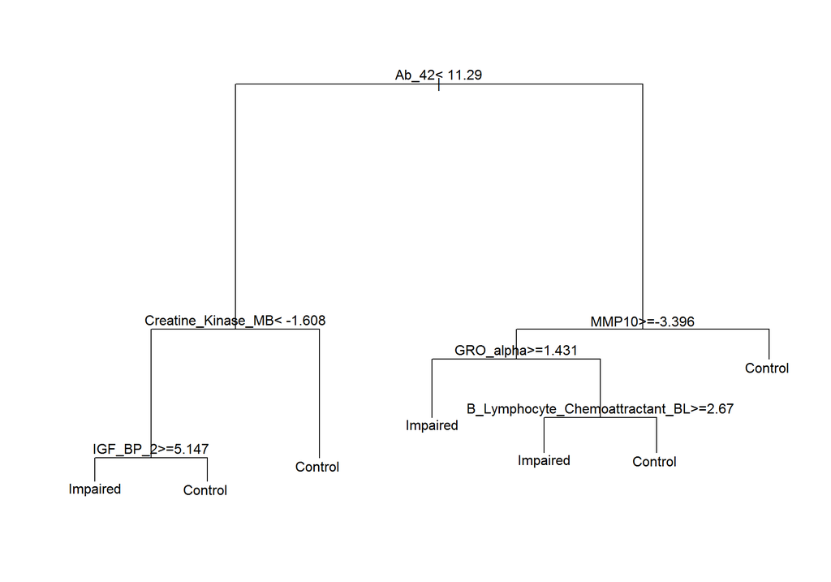

```r
plot(Alz.rpart)
text(Alz.rpart)
```

The functions `plot` and `text` have additional options to make the display more appealing, but it’s easier to use the library `partykit` below. To interpret the tree, we simply follow the branches: for example, if an individual has `Ab_42 < 11.29` and `Creatine_Kinase_MB < -1.608` and `IGF_BP >= 5.147`, then he or she is likely to have mild cognitive impairment.

5. The library `partykit` contains plotting functions that yield more useful and attractive plots. To use it, first convert the `rpart` object you created above using the function `as.party`, and then plot it using the function `plot`. Again, you may have to adjust `fig.height` and `fig.width` inside the chunk header. Can you interpret the terminal nodes?

The library `partykit` provides additional functions for plotting more meaningful trees. The example below shows the resulting tree produced without additional arguments, but you can look at the documentation to find out how to carry out further customization. One of the nice features of the resulting tree is that it shows the purity of the terminal nodes, and the splits are easier to interpret.

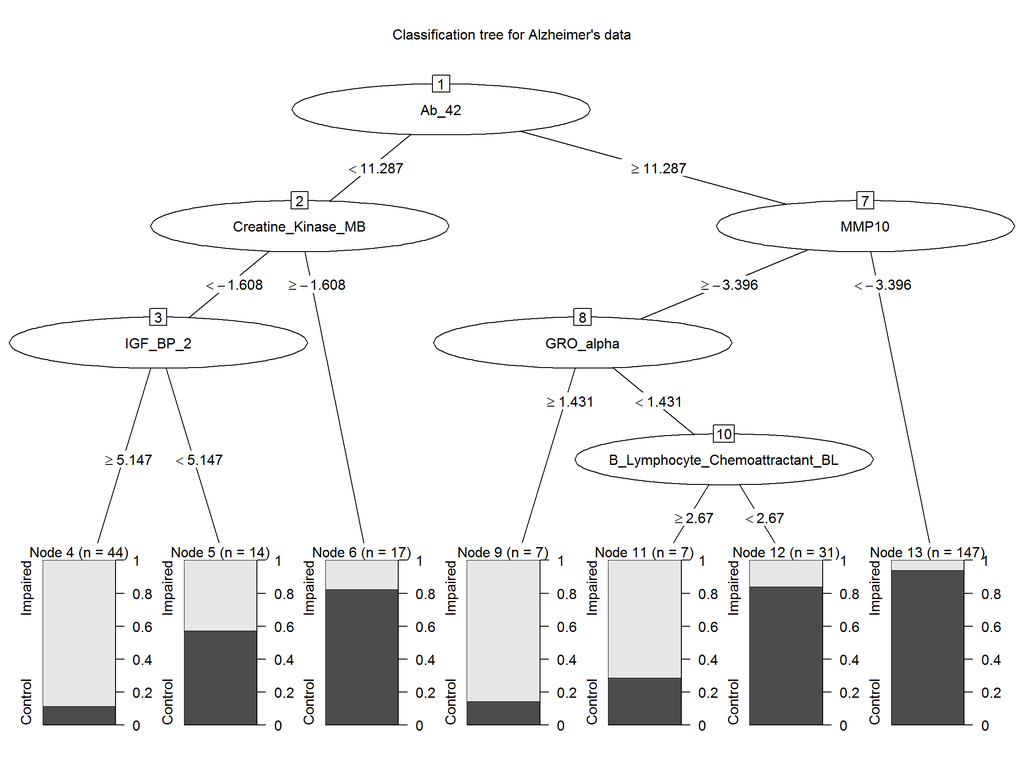

```r
plot(as.party(Alz.rpart), main = "Classification tree for Alzheimer's data")
```

An alternative to `partykit` is to use functions in the library `rattle`, but it does require the installation of additional programs.

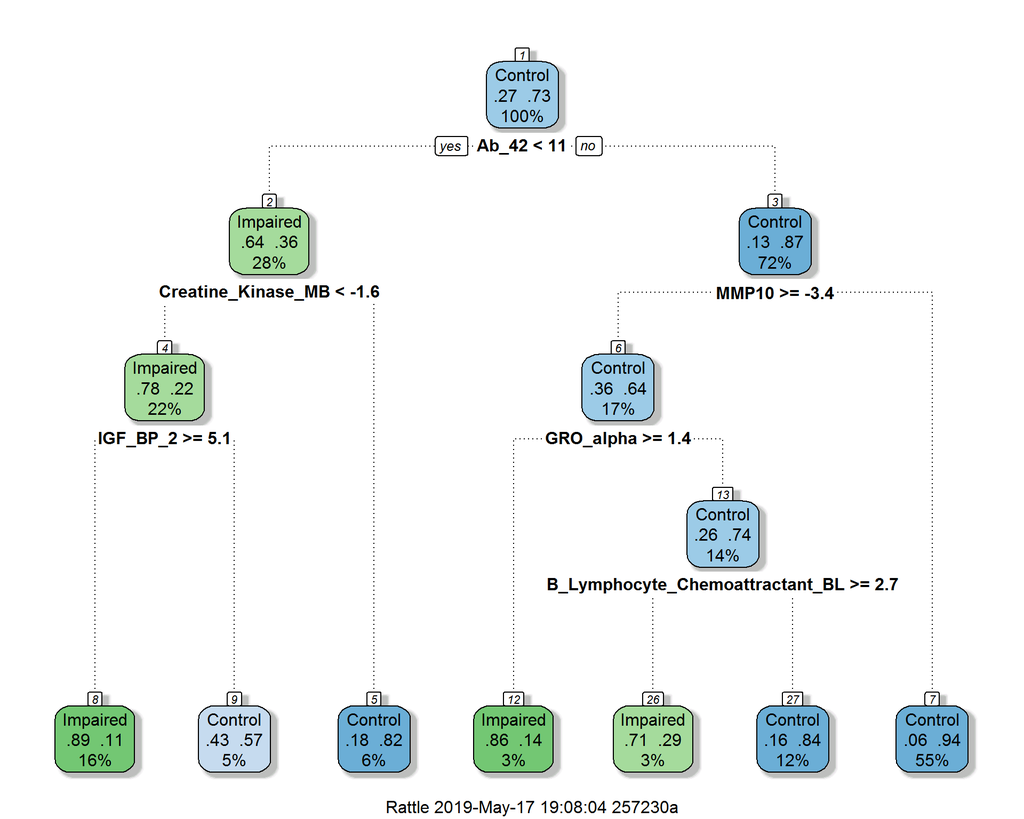

```r
# Comment out this code if you do not have the library `rattle` on your
# computer, or if you are unable to install it
library(rattle)
fancyRpartPlot(Alz.rpart)
```

6. How well does the tree you produced predict the class of the individuals in the test set? Produce a confusion matrix, and compare it with the results you obtained using logistic regression.

The `predict` function for `rpart` objects follows the same syntax that you have seen before for linear or generalized linear models, but you do have to add the additional argument `type = "class"` to get the class predictions instead of the class probabilities. Once we have done so, we can compare the test set predictions to the actual values and then produce a confusion matrix. In the `table` below, note the argument `dnn` that labels the rows and columns of the confusion matrix to make it more informative.

```r
Class.rpart <- predict(Alz.rpart, newdata = testing, type = "class")
table(Class.rpart, testing$Class, dnn = c("Predictions", "Actual"))
```

```
           Actual
Predictions Impaired Control
   Impaired        9       8
   Control         9      40
```

The tree produced above predicts more true positives (`Control`) and fewer negatives (`Impaired`), but it is certainly more interpretable than a logistic regression model.

7. Can we improve the predictions by using random forests? The function to carry out random forests is `randomForest`, and again, the syntax is straightforward, but you will need to add the argument `importance= TRUE` to ensure that the importance of the predictors is assessed. Use the function `summary` to see what objects are stored in the result, and explore a few of them.

```r
Alz.rf <- randomForest(Class ~ ., data = training, importance = TRUE)
```

```r
summary(Alz.rf)
```

```
                Length Class  Mode
call               4   -none- call
type               1   -none- character
predicted        267   factor numeric
err.rate        1500   -none- numeric
confusion          6   -none- numeric
votes            534   matrix numeric
oob.times        267   -none- numeric
classes            2   -none- character
importance       528   -none- numeric
importanceSD     396   -none- numeric
localImportance    0   -none- NULL
proximity          0   -none- NULL
ntree              1   -none- numeric
mtry               1   -none- numeric
forest            14   -none- list
y                267   factor numeric
test               0   -none- NULL
inbag              0   -none- NULL
terms              3   terms  call
```

```r
Alz.rf$confusion
```

```
         Impaired Control class.error
Impaired       32      41  0.56164384
Control         4     190  0.02061856
```

8. To plot a variable importance plot, you can use the function `varImpPlot` with the object you created above as the first argument. However, it isn’t pretty. So, if you want to create one of your own, you will first need to extract the fourth column, the amount by which the variable, on average, decreases the Gini index. Then, decide how many to display, and produce a horizontal barplot in decreasing order of variable importance, and add some colour to it.

We can see from the variable importance plot that `Ab_42` and `tau` seem to be important, but going by the results for the single tree and boxplots above, we can see why: on some bootstrapped datasets, `Ab_42` is the first split, on others it is `tau`.

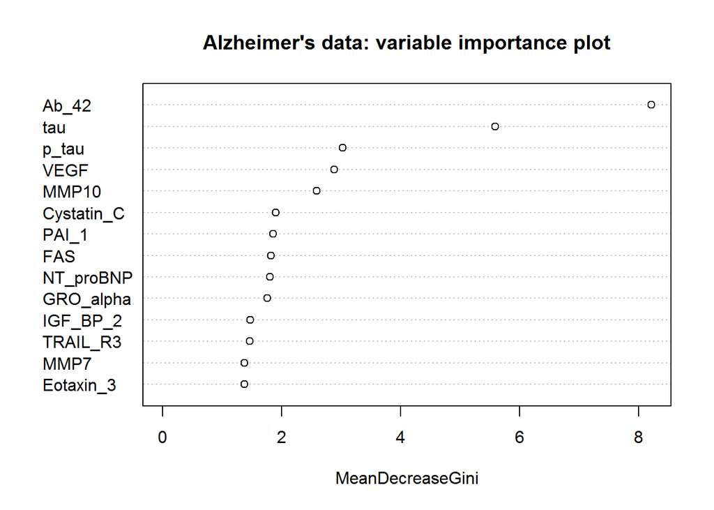

```r
varImpPlot(Alz.rf, n.var = 14, type = 2, main = "Alzheimer's data: variable importance plot")
```

Here is my version of the variable importance plot:

```r
Alz.rf.imp <- Alz.rf$importance
Alz.rf.imp14 <- sort(Alz.rf.imp[, 4], decreasing = TRUE)[1:14]
```

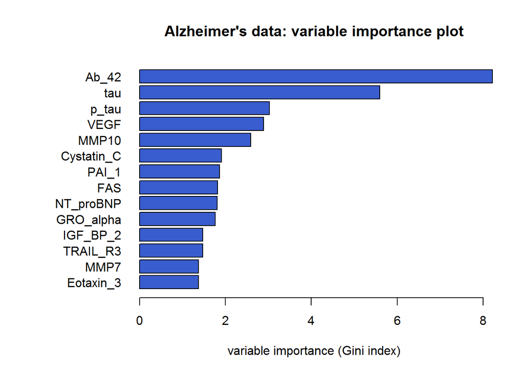

```r
par(oma = c(0, 5, 0, 0))
par(las = 2)
barplot(rev(Alz.rf.imp14), horiz = TRUE, col = "royalblue3", xlab = "variable importance (Gini index)",
    xaxt = "n", main = "Alzheimer's data: variable importance plot")
axis(side = 1, at = c(0, 2, 4, 6, 8), labels = c(0, 2, 4, 6, 8), las = 1)
```

9. How well does the random forest predict compared to a single tree?

```r
Class.rf <- predict(Alz.rf, newdata = testing)
table(Class.rf, testing$Class, dnn = c("Predictions", "Actual"))
```

```
           Actual
Predictions Impaired Control
   Impaired        7       2
   Control        11      46
```

# Cleveland Heart Disease Data

This is a well-known dataset that is available from the [UCI Machine Learning Repository](https://archive.ics.uci.edu/ml/machine-learning-databases/heart-disease/), but the version we’re going to use was obtained from the website of [James *et al*. (2013) *An Introduction to Statistical Learning*](http://www-bcf.usc.edu/~gareth/ISL/data.html).

The solution below provides the *R* code only.

1. The response variable is `AHD`, which has two classes and indicates the presence or absence of heart disease, but make sure that you explore the other variables as well using functions that you have already seen.

```r
levels(Heart$AHD)
```

```
[1] "No"  "Yes"
```

2. Use a single tree as well as random forests to predict the presence or absence of heart disease. Follow the pattern above. How well did you do? Don’t forget to split the data set into training and test sets.

```r
set.seed(584)
TestIndex <- sample(nrow(Heart), size = 0.2 * nrow(Heart), replace = FALSE)
Test <- Heart[TestIndex, ]
Train <- Heart[-TestIndex, ]
```

```r
Heart.rpart <- rpart(AHD ~ ., data = Train)
```

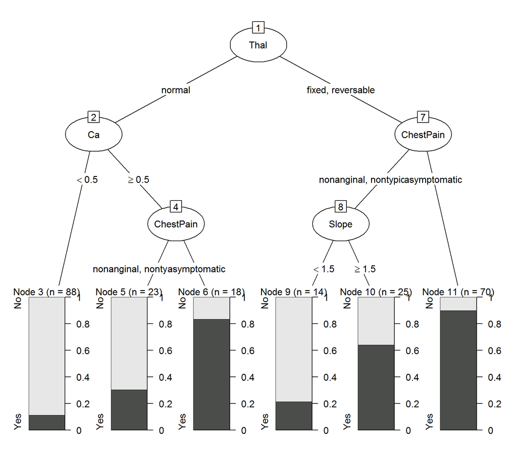

```r
plot(as.party(Heart.rpart))
```

```r
AHD.rpart <- predict(Heart.rpart, newdata = Test, type = "class")
table(AHD.rpart, Test$AHD, dnn = c("Predictions", "Actual"))
```

```
           Actual
Predictions No Yes
        No  30   3
        Yes  6  20
```

```r
Heart.rf <- randomForest(AHD ~ ., data = Train, importance = TRUE)
```

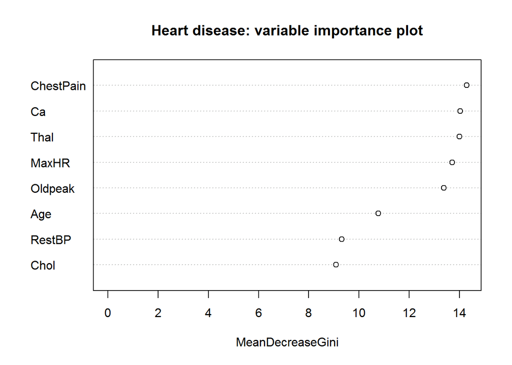

```r
varImpPlot(Heart.rf, n.var = 8, main = "Heart disease: variable importance plot",
    type = 2)
```

```r
AHD.rf <- predict(Heart.rf, newdata = Test)
table(AHD.rf, Test$AHD, dnn = c("Prediction", "Actual"))
```

```
          Actual
Prediction No Yes
       No  30   4
       Yes  6  19
```